# 毕业设计汇报

2017年3月29日

## 工作概要

- 程序编写
  - R语言编程实现《Rough set based 1-v-1 and 1-v-r approaches to support vector machine multi-classification》文献的实验过程
  - 修改前一阶段的代码，提升计算效率
  - LaTeX毕设模板制作

## 程序编写(R)

## 论文基本思路

### 《Rough set based 1-v-1 and 1-v-r approaches to support vector machine multi-classification》

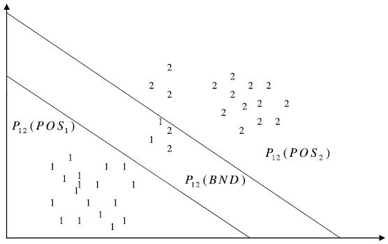

1-v-1

## 论文基本思路

### 《Rough set based 1-v-1 and 1-v-r approaches to support vector machine multi-classification》

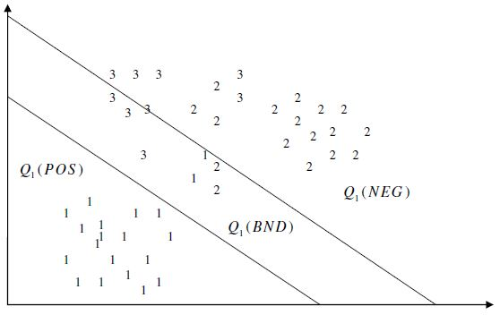

1-v-r

## 论文基本思路

### 《Rough set based 1-v-1 and 1-v-r approaches to support vector machine multi-classification》

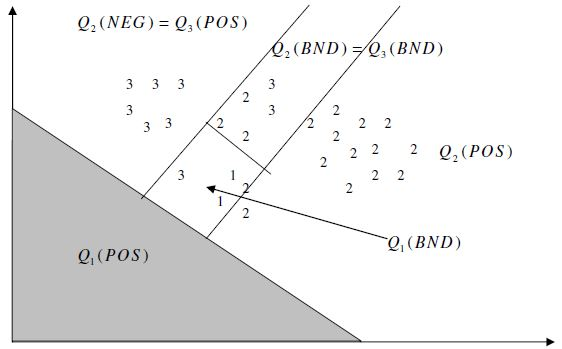

1-v-r

## 论文基本思路

### 《Rough set based 1-v-1 and 1-v-r approaches to support vector machine multi-classification》

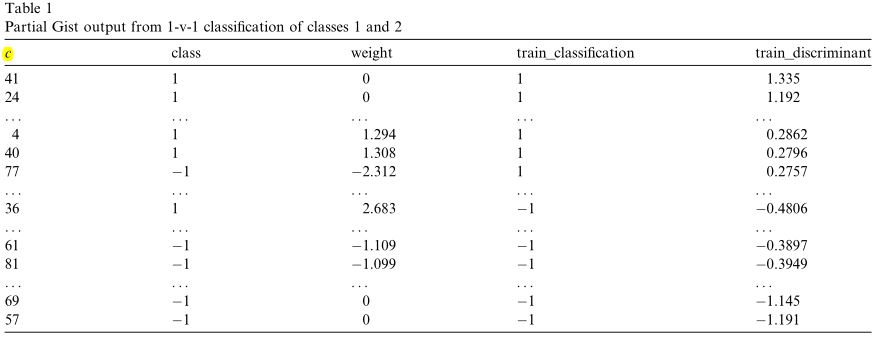

## 程序编写

### Rough Margin Based SVM

- 寻找出最优模型参数，并保存计算最优模型时用的训练集
- 利用最优模型的参数对训练集进行训练
- 利用训练集的 decision value 属性求出文献方法的 Rough Margin 边界值
- 利用边界值来对测试集进行分类，并对比准确率

## 程序编写

```r
load("./12_result.RData")
# 找出性能最好的一次计算结果
source("./fun/fun.find_best_parameters.R")
best.iter<-fun.find_best_parameters(result,c(n,length(proportion),dim(selected.reduct)[1]))
best.result <- result[[best.iter[1]]][[best.iter[2]]][[best.iter[3]]]
# Rough Margin Based SVM
source("./fun/fun.rough_margin_based_SVM.R")
test <- fun.rough_margin_based_SVM(bcdata, best.result)
```

```
## [1]  0.9516625 -0.4726110         NA
##
##       0   1
##   0 218   4
##   1  16 104
##
##       0   1 <NA>
##   0 207   3   12
##   1   2  98   20
```

## 程序编写

### 代码实现

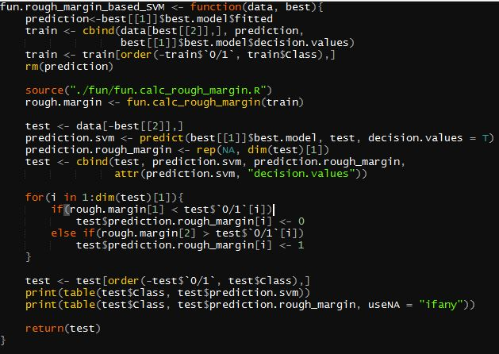